# Starbucks_Capstone_Project

### Starbucks Capstone Challenge

#### Udacity Data Science Nanodegree

Lovelina Richter, December 2020

I. Business Understanding  
II. Data Understanding  
III. Data Preparation  
IV. Build Model  
V. Model Evaluation  
VI. Implementation

### Part I : Business Understanding

Optimizing App Offers With Starbucks

The objective of this project is to understand what influence a customer to purchase or respond to an offer. The analysis is based on customer’s transaction data, demographic profile, and offer type. The goals of this project are: to combine all three datasets, explore the data, and provide an analysis of which demographic responds to an offer. It is important to note that, the dataset provided for this project is limited and a simplified version of the real Starbucks app. The simulator data has one product only, whereas Starbucks sells dozens of products.

### Part II : Data Understanding

The data provided by Starbucks contain three files:

- portfolio.json - containing offer ids and meta data about each offer (duration, type, etc.)
- profile.json - demographic data for each customer
- transcript.json - records for transactions, offers received, offers viewed, and offers completed

##### 2.0 Import libraries needed to complete this project and run Jupyter notebook

```python
#Import libraries
import pandas as pd
import numpy as np
import math
import json
import matplotlib.pyplot as plt
%matplotlib inline
import seaborn as sns
import datetime
import pickle
from datetime import date
from time import time
from IPython.display import display # Allows the use of display() for DataFrames

import visuals as vs
```

```python
# read in the json files
portfolio = pd.read_json('data/portfolio.json', orient='records', lines=True)
profile = pd.read_json('data/profile.json', orient='records', lines=True)
transcript = pd.read_json('data/transcript.json', orient='records', lines=True)
```

##### 2.1 Define Functions that can be reused for data understanding and other steps such as Data Cleanup,

```python
#define function for values count and percentage
def pct_var(col, df):
    '''Takes the column name and dataframe, returns the value counts of column and percentage'''

    pct_cnt = pd.DataFrame(df.groupby(col)[col].count())
    pct_cnt['Percent'] = (pct_cnt[col]/pct_cnt[col].sum())*100
    pct_cnt.sort_values(by='Percent', ascending=True)

    return pct_cnt
```

```python
#Define function for plotting variables
def plot_var(col, df):
    '''Takes the column name and dataframe, returns visual plot of the column'''

    cat_order = df[col].value_counts().index
    sns.countplot(data = df, y = df[col], order=cat_order)
    plt.title('Count')
    plt.ylabel(col)
```

```python
#Define function for plotting corelation of variable to average amount
def plot_ave(col, avecol, df):
    '''Takes the column name, column to be computed average, and dataframe, returns visual plot of the column'''

    ave_comp = df.groupby(df[col])[avecol].mean()
    ave_comp.sort_values(ascending=True)

    ave_comp.plot(kind = 'barh');
    plt.title('Average Spend')
    plt.ylabel(col)
```

```python
#Define function for plotting corellation of variable to frequency/count
def plot_cnt(col, cntcol, df, charttitle):
    '''Takes the column name, column to be counted, and dataframe, returns visual plot of the column'''

    cnt_comp = df.groupby(df[col]).count()[cntcol]
    cnt_comp.sort_values(ascending=True)

    cnt_comp.plot(kind = 'barh');
    plt.title(charttitle)
    plt.xlabel('Count')
    plt.ylabel(col)
```

```python
#Define function for plotting crosstab of variables
def pltcrosstab(col, cntcol, df, charttitle):
    '''Takes the column name, column to be counted, and dataframe, returns crosstab plot of the column'''

    cross_comp = pd.crosstab(df[cntcol], df[col])
    cross_comp.plot.bar(figsize=(5,3));
    plt.legend(title=col)
    plt.title(charttitle)
    plt.show()
```

##### 2.2 Inspect portfolio.json file

**Data Dictionary**

- id (string) - offer id
- offer_type (string) - type of offer ie BOGO, discount, informational
- difficulty (int) - minimum required spend to complete an offer
- reward (int) - reward given for completing an offer
- duration (int) - time for offer to be open, in days
- channels (list of strings)

```python
#Check how many records and columns
portfolio.shape
```

```
(10, 6)
```

```python
#View data values
portfolio.head(10)
```

|  | reward | channels | difficulty | duration | offer_type | id |
| --- | --- | --- | --- | --- | --- | --- |
| 0 | 10 | [email, mobile, social] | 10 | 7 | bogo | ae264e3637204a6fb9bb56bc8210ddfd |
| 1 | 10 | [web, email, mobile, social] | 10 | 5 | bogo | 4d5c57ea9a6940dd891ad53e9dbe8da0 |
| 2 | 0 | [web, email, mobile] | 0 | 4 | informational | 3f207df678b143eea3cee63160fa8bed |
| 3 | 5 | [web, email, mobile] | 5 | 7 | bogo | 9b98b8c7a33c4b65b9aebfe6a799e6d9 |
| 4 | 5 | [web, email] | 20 | 10 | discount | 0b1e1539f2cc45b7b9fa7c272da2e1d7 |
| 5 | 3 | [web, email, mobile, social] | 7 | 7 | discount | 2298d6c36e964ae4a3e7e9706d1fb8c2 |
| 6 | 2 | [web, email, mobile, social] | 10 | 10 | discount | fafdcd668e3743c1bb461111dcafc2a4 |
| 7 | 0 | [email, mobile, social] | 0 | 3 | informational | 5a8bc65990b245e5a138643cd4eb9837 |
| 8 | 5 | [web, email, mobile, social] | 5 | 5 | bogo | f19421c1d4aa40978ebb69ca19b0e20d |
| 9 | 2 | [web, email, mobile] | 10 | 7 | discount | 2906b810c7d4411798c6938adc9daaa5 |

```python
#view data structure
portfolio.info()
```

```
<class 'pandas.core.frame.DataFrame'>
RangeIndex: 10 entries, 0 to 9
Data columns (total 6 columns):
 #   Column      Non-Null Count  Dtype
---  ------      --------------  -----
 0   reward      10 non-null     int64
 1   channels    10 non-null     object
 2   difficulty  10 non-null     int64
 3   duration    10 non-null     int64
 4   offer_type  10 non-null     object
 5   id          10 non-null     object
dtypes: int64(3), object(3)
memory usage: 608.0+ bytes
```

```python
#Visual inspection shows no missing data. but it is good to check to be sure
display(portfolio.isnull().sum())
```

```
reward        0
channels      0
difficulty    0
duration      0
offer_type    0
id            0
dtype: int64
```

> The dataset contain 10 records of offer with corresponding type, reward, duration, and channel for each offer. The dataset does not contain missing values. The following variables will be cleaned in the next section:
> 1. Channel is a categorical variable and will be encoded numerically
> 2. Offer is a categorical variable and will be encoded numerically

##### 2.3 Inspect profile.json file

**Data Dictionary**

- age (int) - age of the customer
- became_member_on (int) - date when customer created an app account
- gender (str) - gender of the customer (note some entries contain 'O' for other rather than M or F)
- id (str) - customer id
- income (float) - customer's income

```python
#Check how many records and columns
profile.shape
```

```
(17000, 5)
```

```python
#View sample data values
profile.head()
```

|  | gender | age | id | became_member_on | income |
| --- | --- | --- | --- | --- | --- |
| 0 | None | 118 | 68be06ca386d4c31939f3a4f0e3dd783 | 20170212 | NaN |
| 1 | F | 55 | 0610b486422d4921ae7d2bf64640c50b | 20170715 | 112000.0 |
| 2 | None | 118 | 38fe809add3b4fcf9315a9694bb96ff5 | 20180712 | NaN |
| 3 | F | 75 | 78afa995795e4d85b5d9ceeca43f5fef | 20170509 | 100000.0 |
| 4 | None | 118 | a03223e636434f42ac4c3df47e8bac43 | 20170804 | NaN |

```python
#view data structure
profile.info()
```

```
<class 'pandas.core.frame.DataFrame'>
RangeIndex: 17000 entries, 0 to 16999
Data columns (total 5 columns):
 #   Column            Non-Null Count  Dtype
---  ------            --------------  -----
 0   gender            14825 non-null  object
 1   age               17000 non-null  int64
 2   id                17000 non-null  object
 3   became_member_on  17000 non-null  int64
 4   income            14825 non-null  float64
dtypes: float64(1), int64(2), object(2)
memory usage: 664.2+ KB
```

```python
#check missing values
display(profile.isnull().sum())
```

```
gender              2175
age                    0
id                     0
became_member_on       0
income              2175
dtype: int64
```

```python
#check if there are duplicate customerids
print(profile.duplicated(subset=['id']).sum())
```

```
0
```

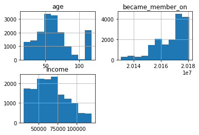

```python
profile.hist();
```

```python
profile.describe().transpose()
```

|  | count | mean | std | min | 25% | 50% | 75% | max |
| --- | --- | --- | --- | --- | --- | --- | --- | --- |
| age | 17000.0 | 6.253141e+01 | 26.738580 | 18.0 | 45.0 | 58.0 | 73.0 | 118.0 |
| became_member_on | 17000.0 | 2.016703e+07 | 11677.499961 | 20130729.0 | 20160526.0 | 20170802.0 | 20171230.0 | 20180726.0 |
| income | 14825.0 | 6.540499e+04 | 21598.299410 | 30000.0 | 49000.0 | 64000.0 | 80000.0 | 120000.0 |

```python
pct_var('gender',profile)
```

| gender | gender | Percent |
| --- | --- | --- |
| F | 6129 | 41.342327 |
| M | 8484 | 57.227656 |
| O | 212 | 1.430017 |

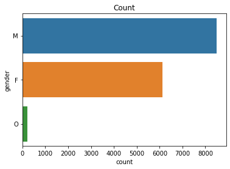

```python
plot_var('gender',profile)
```

> The dataset contain demographic information, with 17,000 records and 5 columns. The following variables will be cleaned in the next section:
> 1. Membership Date will be converted into date feature and converted into number of days as of current date to analyze members' loyalty
> 2. There are age value = 118, these will be converted to NaN
> 3. Gender is categorical value and contain Nan values. Transform and create a new column for gender
> 4. Create a column to group Income
> 5. Create a columm for Age group

##### 2.4 Inspect transcript.json file

**Data Dictionary**

- event (str) - record description (ie transaction, offer received, offer viewed, etc.)
- person (str) - customer id
- time (int) - time in hours since start of test. The data begins at time t=0
- value - (dict of strings) - either an offer id or transaction amount depending on the record

```python
#Check how many records and columns
transcript.shape
```

```
(306534, 4)
```

```python
#View sample data values
transcript.head()
```

|  | person | event | value | time |
| --- | --- | --- | --- | --- |
| 0 | 78afa995795e4d85b5d9ceeca43f5fef | offer received | {'offer id': '9b98b8c7a33c4b65b9aebfe6a799e6d9'} | 0 |
| 1 | a03223e636434f42ac4c3df47e8bac43 | offer received | {'offer id': '0b1e1539f2cc45b7b9fa7c272da2e1d7'} | 0 |
| 2 | e2127556f4f64592b11af22de27a7932 | offer received | {'offer id': '2906b810c7d4411798c6938adc9daaa5'} | 0 |
| 3 | 8ec6ce2a7e7949b1bf142def7d0e0586 | offer received | {'offer id': 'fafdcd668e3743c1bb461111dcafc2a4'} | 0 |
| 4 | 68617ca6246f4fbc85e91a2a49552598 | offer received | {'offer id': '4d5c57ea9a6940dd891ad53e9dbe8da0'} | 0 |

```python
#view data structure
transcript.info()
```

```
<class 'pandas.core.frame.DataFrame'>
RangeIndex: 306534 entries, 0 to 306533
Data columns (total 4 columns):
 #   Column  Non-Null Count   Dtype
---  ------  --------------   -----
 0   person  306534 non-null  object
 1   event   306534 non-null  object
 2   value   306534 non-null  object
 3   time    306534 non-null  int64
dtypes: int64(1), object(3)
memory usage: 9.4+ MB
```

```python
#View unique values and count of event
transcript['event'].value_counts()
```

```
transaction        138953
offer received      76277
offer viewed        57725
offer completed     33579
Name: event, dtype: int64
```

> The dataset contain 300K records of transactions and 4 columns. The following data clean up will be done in the next section.
> 1. Value variable contain the offerid and will be cleaned to extract the offer ID.
> 2. Extract data from value variable based on transaction event and offer type.
> 3. Transformation or joining the variables will be done, depending on each step and result of analysis.

### Part III : Data Preparation

##### 3.0 Copy the dataset into new dataframes which will be used for data preparation

```python
#Backup original data before processing
df_portfolio = portfolio.copy()
df_profile = profile.copy()
df_transcript = transcript.copy()
```

##### 3.1 Portfolio data cleanup

1. Channel is a categorical variable and will be encoded numerically
2. Offer is a categorical variable and will be encoded numerically

```python
 # transform channels to 0 and 1 using one-hot encoding
df_portfolio['web'] = df_portfolio['channels'].apply(lambda x: 1 if 'web' in x else 0)
df_portfolio['email'] = df_portfolio['channels'].apply(lambda x: 1 if 'email' in x else 0)
df_portfolio['mobile'] = df_portfolio['channels'].apply(lambda x: 1 if 'mobile' in x else 0)
df_portfolio['social'] = df_portfolio['channels'].apply(lambda x: 1 if 'social' in x else 0)
```

```python
#check transformation
df_portfolio.head(10)
```

|  | reward | channels | difficulty | duration | offer_type | id | web | email | mobile | social |
| --- | --- | --- | --- | --- | --- | --- | --- | --- | --- | --- |
| 0 | 10 | [email, mobile, social] | 10 | 7 | bogo | ae264e3637204a6fb9bb56bc8210ddfd | 0 | 1 | 1 | 1 |
| 1 | 10 | [web, email, mobile, social] | 10 | 5 | bogo | 4d5c57ea9a6940dd891ad53e9dbe8da0 | 1 | 1 | 1 | 1 |
| 2 | 0 | [web, email, mobile] | 0 | 4 | informational | 3f207df678b143eea3cee63160fa8bed | 1 | 1 | 1 | 0 |
| 3 | 5 | [web, email, mobile] | 5 | 7 | bogo | 9b98b8c7a33c4b65b9aebfe6a799e6d9 | 1 | 1 | 1 | 0 |
| 4 | 5 | [web, email] | 20 | 10 | discount | 0b1e1539f2cc45b7b9fa7c272da2e1d7 | 1 | 1 | 0 | 0 |
| 5 | 3 | [web, email, mobile, social] | 7 | 7 | discount | 2298d6c36e964ae4a3e7e9706d1fb8c2 | 1 | 1 | 1 | 1 |
| 6 | 2 | [web, email, mobile, social] | 10 | 10 | discount | fafdcd668e3743c1bb461111dcafc2a4 | 1 | 1 | 1 | 1 |
| 7 | 0 | [email, mobile, social] | 0 | 3 | informational | 5a8bc65990b245e5a138643cd4eb9837 | 0 | 1 | 1 | 1 |
| 8 | 5 | [web, email, mobile, social] | 5 | 5 | bogo | f19421c1d4aa40978ebb69ca19b0e20d | 1 | 1 | 1 | 1 |
| 9 | 2 | [web, email, mobile] | 10 | 7 | discount | 2906b810c7d4411798c6938adc9daaa5 | 1 | 1 | 1 | 0 |

```python
 # transform offer_type to 0 and 1 using one-hot encoding
df_portfolio['bogo'] = df_portfolio['offer_type'].apply(lambda x: 1 if 'bogo' in x else 0)
df_portfolio['discount'] = df_portfolio['offer_type'].apply(lambda x: 1 if 'discount' in x else 0)
df_portfolio['informational'] = df_portfolio['offer_type'].apply(lambda x: 1 if 'informational' in x else 0)
```

```python
#check transformation
df_portfolio.head(10)
```

|  | reward | channels | difficulty | duration | offer_type | id | web | email | mobile | social | bogo | discount | informational |
| --- | --- | --- | --- | --- | --- | --- | --- | --- | --- | --- | --- | --- | --- |
| 0 | 10 | [email, mobile, social] | 10 | 7 | bogo | ae264e3637204a6fb9bb56bc8210ddfd | 0 | 1 | 1 | 1 | 1 | 0 | 0 |
| 1 | 10 | [web, email, mobile, social] | 10 | 5 | bogo | 4d5c57ea9a6940dd891ad53e9dbe8da0 | 1 | 1 | 1 | 1 | 1 | 0 | 0 |
| 2 | 0 | [web, email, mobile] | 0 | 4 | informational | 3f207df678b143eea3cee63160fa8bed | 1 | 1 | 1 | 0 | 0 | 0 | 1 |
| 3 | 5 | [web, email, mobile] | 5 | 7 | bogo | 9b98b8c7a33c4b65b9aebfe6a799e6d9 | 1 | 1 | 1 | 0 | 1 | 0 | 0 |
| 4 | 5 | [web, email] | 20 | 10 | discount | 0b1e1539f2cc45b7b9fa7c272da2e1d7 | 1 | 1 | 0 | 0 | 0 | 1 | 0 |
| 5 | 3 | [web, email, mobile, social] | 7 | 7 | discount | 2298d6c36e964ae4a3e7e9706d1fb8c2 | 1 | 1 | 1 | 1 | 0 | 1 | 0 |
| 6 | 2 | [web, email, mobile, social] | 10 | 10 | discount | fafdcd668e3743c1bb461111dcafc2a4 | 1 | 1 | 1 | 1 | 0 | 1 | 0 |
| 7 | 0 | [email, mobile, social] | 0 | 3 | informational | 5a8bc65990b245e5a138643cd4eb9837 | 0 | 1 | 1 | 1 | 0 | 0 | 1 |
| 8 | 5 | [web, email, mobile, social] | 5 | 5 | bogo | f19421c1d4aa40978ebb69ca19b0e20d | 1 | 1 | 1 | 1 | 1 | 0 | 0 |
| 9 | 2 | [web, email, mobile] | 10 | 7 | discount | 2906b810c7d4411798c6938adc9daaa5 | 1 | 1 | 1 | 0 | 0 | 1 | 0 |

##### 3.2 Profile Data Cleanup

1. Membership Date will be converted into date feature and converted into number of days/year to analyze members' loyalty
2. There are age value = 118, these will be converted to NaN
3. Transform and create a new column for gender
4. Create a group for Income

```python
df_profile.head()
```

|  | gender | age | id | became_member_on | income |
| --- | --- | --- | --- | --- | --- |
| 0 | None | 118 | 68be06ca386d4c31939f3a4f0e3dd783 | 20170212 | NaN |
| 1 | F | 55 | 0610b486422d4921ae7d2bf64640c50b | 20170715 | 112000.0 |
| 2 | None | 118 | 38fe809add3b4fcf9315a9694bb96ff5 | 20180712 | NaN |
| 3 | F | 75 | 78afa995795e4d85b5d9ceeca43f5fef | 20170509 | 100000.0 |
| 4 | None | 118 | a03223e636434f42ac4c3df47e8bac43 | 20170804 | NaN |

```python
#profile['became_member_on'] = pd.to_datetime(profile['became_member_on'].astype(str)).dt.date
df_profile['became_member_on'] = pd.to_datetime(df_profile['became_member_on'], format='%Y%m%d').dt.date
```

```python
df_profile.head()
```

|  | gender | age | id | became_member_on | income |
| --- | --- | --- | --- | --- | --- |
| 0 | None | 118 | 68be06ca386d4c31939f3a4f0e3dd783 | 2017-02-12 | NaN |
| 1 | F | 55 | 0610b486422d4921ae7d2bf64640c50b | 2017-07-15 | 112000.0 |
| 2 | None | 118 | 38fe809add3b4fcf9315a9694bb96ff5 | 2018-07-12 | NaN |
| 3 | F | 75 | 78afa995795e4d85b5d9ceeca43f5fef | 2017-05-09 | 100000.0 |
| 4 | None | 118 | a03223e636434f42ac4c3df47e8bac43 | 2017-08-04 | NaN |

```python
# compute membership length based on max date of became_member_on('08-26-2018')

# note:I used Max date in the dataset to compute membership length, instead of today(),
# so that the number of days will not result to false positive result or increased membership length

df_profile['ndays'] = datetime.date(2018, 7, 26)  - df_profile['became_member_on']
df_profile['ndays'] = df_profile['ndays'].dt.days
```

```python
#check transformation
df_profile.head()
```

|  | gender | age | id | became_member_on | income | ndays |
| --- | --- | --- | --- | --- | --- | --- |
| 0 | None | 118 | 68be06ca386d4c31939f3a4f0e3dd783 | 2017-02-12 | NaN | 529 |
| 1 | F | 55 | 0610b486422d4921ae7d2bf64640c50b | 2017-07-15 | 112000.0 | 376 |
| 2 | None | 118 | 38fe809add3b4fcf9315a9694bb96ff5 | 2018-07-12 | NaN | 14 |
| 3 | F | 75 | 78afa995795e4d85b5d9ceeca43f5fef | 2017-05-09 | 100000.0 | 443 |
| 4 | None | 118 | a03223e636434f42ac4c3df47e8bac43 | 2017-08-04 | NaN | 356 |

```python
#convert membership to number of years
df_profile['nyear'] = round(df_profile['ndays']/365)
```

```python
#check transformation
df_profile.head()
```

|  | gender | age | id | became_member_on | income | ndays | nyear |
| --- | --- | --- | --- | --- | --- | --- | --- |
| 0 | None | 118 | 68be06ca386d4c31939f3a4f0e3dd783 | 2017-02-12 | NaN | 529 | 1.0 |
| 1 | F | 55 | 0610b486422d4921ae7d2bf64640c50b | 2017-07-15 | 112000.0 | 376 | 1.0 |
| 2 | None | 118 | 38fe809add3b4fcf9315a9694bb96ff5 | 2018-07-12 | NaN | 14 | 0.0 |
| 3 | F | 75 | 78afa995795e4d85b5d9ceeca43f5fef | 2017-05-09 | 100000.0 | 443 | 1.0 |
| 4 | None | 118 | a03223e636434f42ac4c3df47e8bac43 | 2017-08-04 | NaN | 356 | 1.0 |

```python
#check transformation and value counts
df_profile['nyear'].value_counts()
```

```
1.0    6897
0.0    3556
2.0    3503
3.0    2016
4.0     692
5.0     336
Name: nyear, dtype: int64
```

```python
# Drop became_member_on and ndays
df_profile.drop(['became_member_on','ndays'], axis=1, inplace=True)
```

```python
#transform 118 age to numpy NaN
df_profile['age'] = df_profile['age'].apply(lambda x: np.nan if x == 118 else x)
```

```python
#check new structure
df_profile.info()
```

```
<class 'pandas.core.frame.DataFrame'>
RangeIndex: 17000 entries, 0 to 16999
Data columns (total 5 columns):
 #   Column  Non-Null Count  Dtype
---  ------  --------------  -----
 0   gender  14825 non-null  object
 1   age     14825 non-null  float64
 2   id      17000 non-null  object
 3   income  14825 non-null  float64
 4   nyear   17000 non-null  float64
dtypes: float64(3), object(2)
memory usage: 664.2+ KB
```

```python
# transform and create a new column for genderv
# F = 1, M = 2, else 0
df_profile['gender_code'] = df_profile['gender'].apply(lambda x: 1 if x == 'F' else (2 if x == 'M' else 0))
```

```python
#check transformation
df_profile.head(10)
```

|  | gender | age | id | income | nyear | gender_code |
| --- | --- | --- | --- | --- | --- | --- |
| 0 | None | NaN | 68be06ca386d4c31939f3a4f0e3dd783 | NaN | 1.0 | 0 |
| 1 | F | 55.0 | 0610b486422d4921ae7d2bf64640c50b | 112000.0 | 1.0 | 1 |
| 2 | None | NaN | 38fe809add3b4fcf9315a9694bb96ff5 | NaN | 0.0 | 0 |
| 3 | F | 75.0 | 78afa995795e4d85b5d9ceeca43f5fef | 100000.0 | 1.0 | 1 |
| 4 | None | NaN | a03223e636434f42ac4c3df47e8bac43 | NaN | 1.0 | 0 |
| 5 | M | 68.0 | e2127556f4f64592b11af22de27a7932 | 70000.0 | 0.0 | 2 |
| 6 | None | NaN | 8ec6ce2a7e7949b1bf142def7d0e0586 | NaN | 1.0 | 0 |
| 7 | None | NaN | 68617ca6246f4fbc85e91a2a49552598 | NaN | 1.0 | 0 |
| 8 | M | 65.0 | 389bc3fa690240e798340f5a15918d5c | 53000.0 | 0.0 | 2 |
| 9 | None | NaN | 8974fc5686fe429db53ddde067b88302 | NaN | 2.0 | 0 |

```python
# transform and create a group column for Income
# 1 if <=50000,
# 2 if x > 50000 and x < 70000,
# 3 if x>= 70000 else 0

df_profile['income_code'] = df_profile['income'].apply(lambda x: 1 if x <= 50000 else (2 if x > 50000 and x < 70000 else (3 if x >= 70000 else 0)))
```

```python
# transform and create a group column for Age
# 1 if <=30,
# 2 if x > 30 and x < 60,
#3 if x>= 60 else 0

df_profile['age_code'] = df_profile['age'].apply(lambda x: 1 if x <= 30 else (2 if x > 30 and x < 60 else (3 if x >= 60 else 0)))
```

```python
# Drop age and income
df_profile.drop(['age','income'], axis=1, inplace=True)
```

```python
#check transformation
df_profile.head(10)
```

|  | gender | id | nyear | gender_code | income_code | age_code |
| --- | --- | --- | --- | --- | --- | --- |
| 0 | None | 68be06ca386d4c31939f3a4f0e3dd783 | 1.0 | 0 | 0 | 0 |
| 1 | F | 0610b486422d4921ae7d2bf64640c50b | 1.0 | 1 | 3 | 2 |
| 2 | None | 38fe809add3b4fcf9315a9694bb96ff5 | 0.0 | 0 | 0 | 0 |
| 3 | F | 78afa995795e4d85b5d9ceeca43f5fef | 1.0 | 1 | 3 | 3 |
| 4 | None | a03223e636434f42ac4c3df47e8bac43 | 1.0 | 0 | 0 | 0 |
| 5 | M | e2127556f4f64592b11af22de27a7932 | 0.0 | 2 | 3 | 3 |
| 6 | None | 8ec6ce2a7e7949b1bf142def7d0e0586 | 1.0 | 0 | 0 | 0 |
| 7 | None | 68617ca6246f4fbc85e91a2a49552598 | 1.0 | 0 | 0 | 0 |
| 8 | M | 389bc3fa690240e798340f5a15918d5c | 0.0 | 2 | 2 | 3 |
| 9 | None | 8974fc5686fe429db53ddde067b88302 | 2.0 | 0 | 0 | 0 |

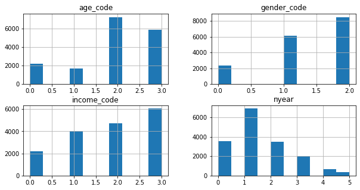

```python
#plot transformed features
df_profile.hist(figsize=(10,5));
```

> 1. Most number of customer
>    - by age is between 30 and 60yo.
>    - by gender is Male
>    - by Income is more than $70,000
>    - by Membership lenght (in years) is 1 year

##### 3.3 Transcript Data Cleanup

1. Value variable contain the offerid and will be cleaned to extract the offer ID.
2. Extract data from value variable based on transaction event and offer type.
3. Transformation or joining the variables will be done, depending on each step and result of analysis.

```python
#Check current data
df_transcript.head()
```

|  | person | event | value | time |
| --- | --- | --- | --- | --- |
| 0 | 78afa995795e4d85b5d9ceeca43f5fef | offer received | {'offer id': '9b98b8c7a33c4b65b9aebfe6a799e6d9'} | 0 |
| 1 | a03223e636434f42ac4c3df47e8bac43 | offer received | {'offer id': '0b1e1539f2cc45b7b9fa7c272da2e1d7'} | 0 |
| 2 | e2127556f4f64592b11af22de27a7932 | offer received | {'offer id': '2906b810c7d4411798c6938adc9daaa5'} | 0 |
| 3 | 8ec6ce2a7e7949b1bf142def7d0e0586 | offer received | {'offer id': 'fafdcd668e3743c1bb461111dcafc2a4'} | 0 |
| 4 | 68617ca6246f4fbc85e91a2a49552598 | offer received | {'offer id': '4d5c57ea9a6940dd891ad53e9dbe8da0'} | 0 |

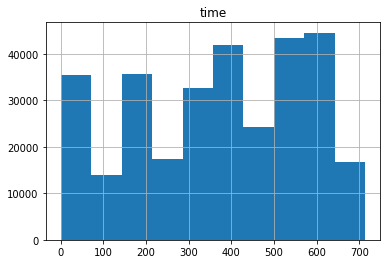

```python
#check numerical variables data
df_transcript.hist();
```

```python
# extract offer_id from value field
df_transcript['offer_id'] = df_transcript['value'].apply(lambda x: x['offer_id'] if 'offer_id' in x else (x['offer id'] if 'offer id' in x else None))
```

```python
#Check transformed value
df_transcript.head()
```

|  | person | event | value | time | offer_id |
| --- | --- | --- | --- | --- | --- |
| 0 | 78afa995795e4d85b5d9ceeca43f5fef | offer received | {'offer id': '9b98b8c7a33c4b65b9aebfe6a799e6d9'} | 0 | 9b98b8c7a33c4b65b9aebfe6a799e6d9 |
| 1 | a03223e636434f42ac4c3df47e8bac43 | offer received | {'offer id': '0b1e1539f2cc45b7b9fa7c272da2e1d7'} | 0 | 0b1e1539f2cc45b7b9fa7c272da2e1d7 |
| 2 | e2127556f4f64592b11af22de27a7932 | offer received | {'offer id': '2906b810c7d4411798c6938adc9daaa5'} | 0 | 2906b810c7d4411798c6938adc9daaa5 |
| 3 | 8ec6ce2a7e7949b1bf142def7d0e0586 | offer received | {'offer id': 'fafdcd668e3743c1bb461111dcafc2a4'} | 0 | fafdcd668e3743c1bb461111dcafc2a4 |
| 4 | 68617ca6246f4fbc85e91a2a49552598 | offer received | {'offer id': '4d5c57ea9a6940dd891ad53e9dbe8da0'} | 0 | 4d5c57ea9a6940dd891ad53e9dbe8da0 |

```python
#check value of time variable
df_transcript['time'].value_counts()
```

```
408    17030
576    17015
504    16822
336    16302
168    16150
       ...
318      940
330      938
156      914
162      910
150      894
Name: time, Length: 120, dtype: int64
```

```python
#check data value and count of events
pct_var('event',df_transcript)
```

| event | event | Percent |
| --- | --- | --- |
| offer completed | 33579 | 10.954413 |
| offer received | 76277 | 24.883700 |
| offer viewed | 57725 | 18.831516 |
| transaction | 138953 | 45.330371 |

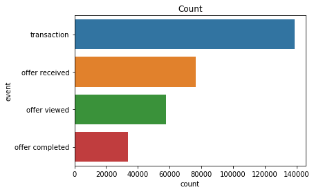

```python
#check data value and count of events
plot_var('event',df_transcript)
```

```python
#check data value and count of offer
pct_var('offer_id',df_transcript)
```

| offer_id | offer_id | Percent |
| --- | --- | --- |
| 0b1e1539f2cc45b7b9fa7c272da2e1d7 | 13751 | 8.205584 |
| 2298d6c36e964ae4a3e7e9706d1fb8c2 | 20139 | 12.017472 |
| 2906b810c7d4411798c6938adc9daaa5 | 15767 | 9.408585 |
| 3f207df678b143eea3cee63160fa8bed | 11761 | 7.018099 |
| 4d5c57ea9a6940dd891ad53e9dbe8da0 | 18222 | 10.873548 |
| 5a8bc65990b245e5a138643cd4eb9837 | 14305 | 8.536171 |
| 9b98b8c7a33c4b65b9aebfe6a799e6d9 | 16202 | 9.668160 |
| ae264e3637204a6fb9bb56bc8210ddfd | 18062 | 10.778071 |
| f19421c1d4aa40978ebb69ca19b0e20d | 19131 | 11.415972 |
| fafdcd668e3743c1bb461111dcafc2a4 | 20241 | 12.078338 |

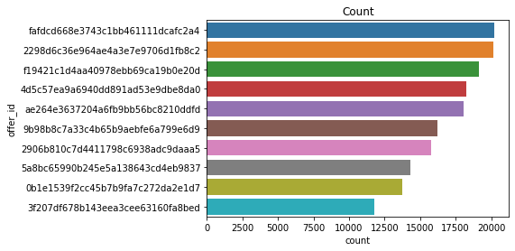

```python
#check data value and count of events
plot_var('offer_id',df_transcript)
```

```python
# check how many times the offer was sent
df_transcript[df_transcript['event']=='offer received']['time'].unique()
```

```
array([  0, 168, 336, 408, 504, 576], dtype=int64)
```

```python
# check how many times the offer was viewed
df_transcript[df_transcript['event']=='offer viewed']['time'].unique()
```

```
array([  0,   6,  12,  18,  24,  30,  36,  42,  48,  54,  60,  66,  72,
        78,  84,  90,  96, 102, 108, 114, 120, 126, 132, 138, 144, 150,
       156, 162, 168, 174, 180, 186, 192, 198, 204, 210, 216, 222, 228,
       234, 240, 246, 252, 258, 264, 270, 276, 282, 288, 294, 300, 306,
       312, 318, 324, 330, 336, 342, 348, 354, 360, 366, 372, 378, 384,
       390, 396, 402, 408, 414, 420, 426, 432, 438, 444, 450, 456, 462,
       468, 474, 480, 486, 492, 498, 504, 510, 516, 522, 528, 534, 540,
       546, 552, 558, 564, 570, 576, 582, 588, 594, 600, 606, 612, 618,
       624, 630, 636, 642, 648, 654, 660, 666, 672, 678, 684, 690, 696,
       702, 708, 714], dtype=int64)
```

```python
# check how many times the offer was completed
df_transcript[df_transcript['event']=='offer completed']['time'].unique()
```

```
array([  0,   6,  12,  18,  24,  30,  36,  42,  48,  54,  60,  66,  72,
        78,  84,  90,  96, 102, 108, 114, 120, 126, 132, 138, 144, 150,
       156, 162, 168, 174, 180, 186, 192, 198, 204, 210, 216, 222, 228,
       234, 240, 246, 252, 258, 264, 270, 276, 282, 288, 294, 300, 306,
       312, 318, 324, 330, 336, 342, 348, 354, 360, 366, 372, 378, 384,
       390, 396, 402, 408, 414, 420, 426, 432, 438, 444, 450, 456, 462,
       468, 474, 480, 486, 492, 498, 504, 510, 516, 522, 528, 534, 540,
       546, 552, 558, 564, 570, 576, 582, 588, 594, 600, 606, 612, 618,
       624, 630, 636, 642, 648, 654, 660, 666, 672, 678, 684, 690, 696,
       702, 708, 714], dtype=int64)
```

```python
# view sample record of one customer to understand how data is saved per customer
df_transcript[df_transcript['person']=='a03223e636434f42ac4c3df47e8bac43'].sort_values('offer_id')
```

|  | person | event | value | time | offer_id |
| --- | --- | --- | --- | --- | --- |
| 1 | a03223e636434f42ac4c3df47e8bac43 | offer received | {'offer id': '0b1e1539f2cc45b7b9fa7c272da2e1d7'} | 0 | 0b1e1539f2cc45b7b9fa7c272da2e1d7 |
| 15562 | a03223e636434f42ac4c3df47e8bac43 | offer viewed | {'offer id': '0b1e1539f2cc45b7b9fa7c272da2e1d7'} | 6 | 0b1e1539f2cc45b7b9fa7c272da2e1d7 |
| 201573 | a03223e636434f42ac4c3df47e8bac43 | offer received | {'offer id': '0b1e1539f2cc45b7b9fa7c272da2e1d7'} | 504 | 0b1e1539f2cc45b7b9fa7c272da2e1d7 |
| 245125 | a03223e636434f42ac4c3df47e8bac43 | offer received | {'offer id': '0b1e1539f2cc45b7b9fa7c272da2e1d7'} | 576 | 0b1e1539f2cc45b7b9fa7c272da2e1d7 |
| 281785 | a03223e636434f42ac4c3df47e8bac43 | offer viewed | {'offer id': '0b1e1539f2cc45b7b9fa7c272da2e1d7'} | 624 | 0b1e1539f2cc45b7b9fa7c272da2e1d7 |
| 110829 | a03223e636434f42ac4c3df47e8bac43 | offer received | {'offer id': '3f207df678b143eea3cee63160fa8bed'} | 336 | 3f207df678b143eea3cee63160fa8bed |
| 123539 | a03223e636434f42ac4c3df47e8bac43 | offer viewed | {'offer id': '3f207df678b143eea3cee63160fa8bed'} | 336 | 3f207df678b143eea3cee63160fa8bed |
| 150599 | a03223e636434f42ac4c3df47e8bac43 | offer received | {'offer id': '5a8bc65990b245e5a138643cd4eb9837'} | 408 | 5a8bc65990b245e5a138643cd4eb9837 |
| 90553 | a03223e636434f42ac4c3df47e8bac43 | transaction | {'amount': 1.09} | 234 | None |
| 97700 | a03223e636434f42ac4c3df47e8bac43 | transaction | {'amount': 3.5} | 264 | None |
| 277104 | a03223e636434f42ac4c3df47e8bac43 | transaction | {'amount': 0.06} | 612 | None |

```python
#check structure
df_transcript.info()
```

```
<class 'pandas.core.frame.DataFrame'>
RangeIndex: 306534 entries, 0 to 306533
Data columns (total 5 columns):
 #   Column    Non-Null Count   Dtype
---  ------    --------------   -----
 0   person    306534 non-null  object
 1   event     306534 non-null  object
 2   value     306534 non-null  object
 3   time      306534 non-null  int64
 4   offer_id  167581 non-null  object
dtypes: int64(1), object(4)
memory usage: 11.7+ MB
```

```python
#save the value as key for transaction
transaction_keys = df_transcript['value'].apply(lambda x: str(list(x.keys())))
```

```python
#check how key is saved
transaction_keys
```

```
0         ['offer id']
1         ['offer id']
2         ['offer id']
3         ['offer id']
4         ['offer id']
              ...
306529      ['amount']
306530      ['amount']
306531      ['amount']
306532      ['amount']
306533      ['amount']
Name: value, Length: 306534, dtype: object
```

```python
#matrix of offer value and event
#to understand how data is saved in value variable in relation to event

pd.crosstab(transaction_keys, df_transcript['event'])
```

| event value | offer completed | offer received | offer viewed | transaction |
| --- | --- | --- | --- | --- |
| ['amount'] | 0 | 0 | 0 | 138953 |
| ['offer id'] | 0 | 76277 | 57725 | 0 |
| ['offer_id', 'reward'] | 33579 | 0 | 0 | 0 |

> Data shows, only transaction record has amount and offer completed has reward.

```python
# add columns for reward and column based on the offer(value) to df_transcript
for i in ['reward', 'amount']:
    df_transcript[i] = df_transcript['value'].apply(lambda x: x[i] if i in x else None)

df_transcript['offer_id'] = df_transcript['value'].apply(lambda x: x['offer_id'] if 'offer_id' in x else (x['offer id'] if 'offer id' in x else None))
df_transcript.drop('value', 1, inplace=True)
```

```python
# check added columns
df_transcript.shape
```

```
(306534, 6)
```

```python
#check transformed data and added columns
df_transcript.head()
```

|  | person | event | time | offer_id | reward | amount |
| --- | --- | --- | --- | --- | --- | --- |
| 0 | 78afa995795e4d85b5d9ceeca43f5fef | offer received | 0 | 9b98b8c7a33c4b65b9aebfe6a799e6d9 | NaN | NaN |
| 1 | a03223e636434f42ac4c3df47e8bac43 | offer received | 0 | 0b1e1539f2cc45b7b9fa7c272da2e1d7 | NaN | NaN |
| 2 | e2127556f4f64592b11af22de27a7932 | offer received | 0 | 2906b810c7d4411798c6938adc9daaa5 | NaN | NaN |
| 3 | 8ec6ce2a7e7949b1bf142def7d0e0586 | offer received | 0 | fafdcd668e3743c1bb461111dcafc2a4 | NaN | NaN |
| 4 | 68617ca6246f4fbc85e91a2a49552598 | offer received | 0 | 4d5c57ea9a6940dd891ad53e9dbe8da0 | NaN | NaN |

```python
df_transcript[df_transcript['person']=='a03223e636434f42ac4c3df47e8bac43'].sort_values('offer_id')
```

|  | person | event | time | offer_id | reward | amount |
| --- | --- | --- | --- | --- | --- | --- |
| 1 | a03223e636434f42ac4c3df47e8bac43 | offer received | 0 | 0b1e1539f2cc45b7b9fa7c272da2e1d7 | NaN | NaN |
| 15562 | a03223e636434f42ac4c3df47e8bac43 | offer viewed | 6 | 0b1e1539f2cc45b7b9fa7c272da2e1d7 | NaN | NaN |
| 201573 | a03223e636434f42ac4c3df47e8bac43 | offer received | 504 | 0b1e1539f2cc45b7b9fa7c272da2e1d7 | NaN | NaN |
| 245125 | a03223e636434f42ac4c3df47e8bac43 | offer received | 576 | 0b1e1539f2cc45b7b9fa7c272da2e1d7 | NaN | NaN |
| 281785 | a03223e636434f42ac4c3df47e8bac43 | offer viewed | 624 | 0b1e1539f2cc45b7b9fa7c272da2e1d7 | NaN | NaN |
| 110829 | a03223e636434f42ac4c3df47e8bac43 | offer received | 336 | 3f207df678b143eea3cee63160fa8bed | NaN | NaN |
| 123539 | a03223e636434f42ac4c3df47e8bac43 | offer viewed | 336 | 3f207df678b143eea3cee63160fa8bed | NaN | NaN |
| 150599 | a03223e636434f42ac4c3df47e8bac43 | offer received | 408 | 5a8bc65990b245e5a138643cd4eb9837 | NaN | NaN |
| 90553 | a03223e636434f42ac4c3df47e8bac43 | transaction | 234 | None | NaN | 1.09 |
| 97700 | a03223e636434f42ac4c3df47e8bac43 | transaction | 264 | None | NaN | 3.50 |
| 277104 | a03223e636434f42ac4c3df47e8bac43 | transaction | 612 | None | NaN | 0.06 |

> All three dataset have been cleaned and transformed based on the findings from Part1. Next step is to merge the datasets to be used for features analysis and modelling. Further transformation and cleanup may be needed depending upon the result of each step and analysis.

#### 3.4 Merge Datasets

Merge dataset for analysis and building the model.

```python
#Merge event offer completed with time and reward
df1 = pd.merge(df_transcript.loc[df_transcript['event'] == 'offer completed'],
               df_transcript.loc[df_transcript['event'] == 'transaction', ['person', 'event', 'time']],
               on=['person', 'time'])
```

```python
#check how many records
df1.shape
```

```
(33579, 7)
```

```python
#check transformation
df1.head()
```

|  | person | event_x | time | offer_id | reward | amount | event_y |
| --- | --- | --- | --- | --- | --- | --- | --- |
| 0 | 9fa9ae8f57894cc9a3b8a9bbe0fc1b2f | offer completed | 0 | 2906b810c7d4411798c6938adc9daaa5 | 2.0 | NaN | transaction |
| 1 | fe97aa22dd3e48c8b143116a8403dd52 | offer completed | 0 | fafdcd668e3743c1bb461111dcafc2a4 | 2.0 | NaN | transaction |
| 2 | 629fc02d56414d91bca360decdfa9288 | offer completed | 0 | 9b98b8c7a33c4b65b9aebfe6a799e6d9 | 5.0 | NaN | transaction |
| 3 | 676506bad68e4161b9bbaffeb039626b | offer completed | 0 | ae264e3637204a6fb9bb56bc8210ddfd | 10.0 | NaN | transaction |
| 4 | 8f7dd3b2afe14c078eb4f6e6fe4ba97d | offer completed | 0 | 4d5c57ea9a6940dd891ad53e9dbe8da0 | 10.0 | NaN | transaction |

```python
#Merge event offer viewed with time
df1 = pd.merge(df_transcript.loc[df_transcript['event'] == 'offer viewed'].reset_index(),
               df_transcript.loc[df_transcript['event'] == 'offer received', ['person', 'time', 'offer_id']],
               on=['person', 'offer_id'])
```

```python
#check number of records
df1.shape
```

```
(79329, 8)
```

```python
#check transformation
df1.head()
```

|  | index | person | event | time_x | offer_id | reward | amount | time_y |
| --- | --- | --- | --- | --- | --- | --- | --- | --- |
| 0 | 12650 | 389bc3fa690240e798340f5a15918d5c | offer viewed | 0 | f19421c1d4aa40978ebb69ca19b0e20d | NaN | NaN | 0 |
| 1 | 12650 | 389bc3fa690240e798340f5a15918d5c | offer viewed | 0 | f19421c1d4aa40978ebb69ca19b0e20d | NaN | NaN | 504 |
| 2 | 214275 | 389bc3fa690240e798340f5a15918d5c | offer viewed | 504 | f19421c1d4aa40978ebb69ca19b0e20d | NaN | NaN | 0 |
| 3 | 214275 | 389bc3fa690240e798340f5a15918d5c | offer viewed | 504 | f19421c1d4aa40978ebb69ca19b0e20d | NaN | NaN | 504 |
| 4 | 12651 | d1ede868e29245ea91818a903fec04c6 | offer viewed | 0 | 5a8bc65990b245e5a138643cd4eb9837 | NaN | NaN | 0 |

```python
#transpose time received and time viewed for offer
dfviews = pd.merge(df_transcript.loc[df_transcript['event'] == 'offer received', ['person', 'offer_id', 'time']],
                 df_transcript.loc[df_transcript['event'] == 'offer viewed', ['person', 'offer_id', 'time']],
                 on=['person', 'offer_id'], how='left', suffixes=['_received', '_viewed'])
```

```python
dfviews = dfviews.loc[(dfviews['time_viewed'] >= dfviews['time_received']) | (dfviews['time_viewed'].isnull())]
```

```python
dfviews = pd.concat((dfviews.groupby(['person', 'offer_id', 'time_viewed']).agg({'time_received': 'max'}).reset_index(),
                  dfviews.loc[dfviews['time_viewed'].isnull()]),
                  axis=0, sort=True)
```

```python
#check added columns
dfviews.head()
```

|  | offer_id | person | time_received | time_viewed |
| --- | --- | --- | --- | --- |
| 0 | 3f207df678b143eea3cee63160fa8bed | 0009655768c64bdeb2e877511632db8f | 336 | 372.0 |
| 1 | 5a8bc65990b245e5a138643cd4eb9837 | 0009655768c64bdeb2e877511632db8f | 168 | 192.0 |
| 2 | f19421c1d4aa40978ebb69ca19b0e20d | 0009655768c64bdeb2e877511632db8f | 408 | 456.0 |
| 3 | fafdcd668e3743c1bb461111dcafc2a4 | 0009655768c64bdeb2e877511632db8f | 504 | 540.0 |
| 4 | f19421c1d4aa40978ebb69ca19b0e20d | 00116118485d4dfda04fdbaba9a87b5c | 168 | 216.0 |

```python
#check how many records
dfviews.shape
```

```
(73717, 4)
```

```python
#transpose and add column for time completed
dfcomp = pd.merge(dfviews,
                df_transcript.loc[df_transcript['event'] == 'offer completed', ['person', 'offer_id', 'time', 'reward']],
                on=['person', 'offer_id'], how='left').rename(columns={'time': 'time_completed'})
```

```python
dfcomp.loc[(dfcomp['time_viewed'].isnull()) | (dfcomp['time_viewed'] > dfcomp['time_completed']), ['time_completed', 'reward']] = (np.nan, np.nan)
dfcomp.drop_duplicates(inplace=True)
```

```python
dfcomp = pd.concat(
    (dfcomp.groupby(['person', 'offer_id', 'time_completed', 'reward']).agg({'time_viewed': 'max', 'time_received': 'max'}).reset_index(),
     dfcomp.loc[dfcomp['time_completed'].isnull()]),
    axis=0, sort=True)
```

```python
#check added column
dfcomp.head()
```

|  | offer_id | person | reward | time_completed | time_received | time_viewed |
| --- | --- | --- | --- | --- | --- | --- |
| 0 | 0b1e1539f2cc45b7b9fa7c272da2e1d7 | 0011e0d4e6b944f998e987f904e8c1e5 | 5.0 | 576.0 | 408 | 432.0 |
| 1 | 2298d6c36e964ae4a3e7e9706d1fb8c2 | 0011e0d4e6b944f998e987f904e8c1e5 | 3.0 | 252.0 | 168 | 186.0 |
| 2 | 9b98b8c7a33c4b65b9aebfe6a799e6d9 | 0011e0d4e6b944f998e987f904e8c1e5 | 5.0 | 576.0 | 504 | 516.0 |
| 3 | 4d5c57ea9a6940dd891ad53e9dbe8da0 | 0020c2b971eb4e9188eac86d93036a77 | 10.0 | 510.0 | 408 | 426.0 |
| 4 | fafdcd668e3743c1bb461111dcafc2a4 | 0020c2b971eb4e9188eac86d93036a77 | 2.0 | 54.0 | 0 | 12.0 |

```python
#check number of records
dfcomp.shape
```

```
(76673, 6)
```

```python
# create customer transaction dataframe
dfcustomer = pd.merge(dfcomp,
                   df_transcript.loc[df_transcript['event'] == 'transaction', ['person', 'time', 'amount']],
                   left_on=['person', 'time_completed'], right_on=['person', 'time'], how='outer').rename(columns={'time': 'time_transaction'})
```

```python
dfcustomer['time'] = dfcustomer['time_received']
dfcustomer.loc[dfcustomer['time'].isnull(), 'time'] = dfcustomer['time_transaction']
```

```python
dfcustomer.shape
```

```
(192096, 9)
```

```python
#remove duplicate customer, completed same offerid
dfcustomer.sort_values(['person', 'offer_id', 'time', 'time_completed'], inplace=True)
dfcustomer = dfcustomer.drop_duplicates(['person', 'offer_id', 'time'])
```

```python
dfcustomer = dfcustomer[['person', 'offer_id', 'time', 'time_received', 'time_viewed', 'time_completed', 'time_transaction', 'amount', 'reward']]
```

```python
#check
dfcustomer.head()
```

|  | person | offer_id | time | time_received | time_viewed | time_completed | time_transaction | amount | reward |
| --- | --- | --- | --- | --- | --- | --- | --- | --- | --- |
| 24618 | 0009655768c64bdeb2e877511632db8f | 2906b810c7d4411798c6938adc9daaa5 | 576.0 | 576.0 | NaN | NaN | NaN | NaN | NaN |
| 24614 | 0009655768c64bdeb2e877511632db8f | 3f207df678b143eea3cee63160fa8bed | 336.0 | 336.0 | 372.0 | NaN | NaN | NaN | NaN |
| 24615 | 0009655768c64bdeb2e877511632db8f | 5a8bc65990b245e5a138643cd4eb9837 | 168.0 | 168.0 | 192.0 | NaN | NaN | NaN | NaN |
| 24616 | 0009655768c64bdeb2e877511632db8f | f19421c1d4aa40978ebb69ca19b0e20d | 408.0 | 408.0 | 456.0 | NaN | NaN | NaN | NaN |
| 24617 | 0009655768c64bdeb2e877511632db8f | fafdcd668e3743c1bb461111dcafc2a4 | 504.0 | 504.0 | 540.0 | NaN | NaN | NaN | NaN |

```python
#check number of records
dfcustomer.shape
```

```
(188234, 9)
```

```python
#merge customer transaction and profile
df1 = pd.merge(dfcustomer,
               df_portfolio.rename(columns={'reward': 'rewardvalue', 'id': 'offer_id'}),
               on='offer_id', how='left')
```

```python
#check combined columns
df1.head()
```

|  | person | offer_id | time | time_received | time_viewed | time_completed | time_transaction | amount | reward | rewardvalue | ... | difficulty | duration | offer_type | web | email | mobile | social | bogo | discount | informational |
| --- | --- | --- | --- | --- | --- | --- | --- | --- | --- | --- | --- | --- | --- | --- | --- | --- | --- | --- | --- | --- | --- |
| 0 | 0009655768c64bdeb2e877511632db8f | 2906b810c7d4411798c6938adc9daaa5 | 576.0 | 576.0 | NaN | NaN | NaN | NaN | NaN | 2.0 | ... | 10.0 | 7.0 | discount | 1.0 | 1.0 | 1.0 | 0.0 | 0.0 | 1.0 | 0.0 |
| 1 | 0009655768c64bdeb2e877511632db8f | 3f207df678b143eea3cee63160fa8bed | 336.0 | 336.0 | 372.0 | NaN | NaN | NaN | NaN | 0.0 | ... | 0.0 | 4.0 | informational | 1.0 | 1.0 | 1.0 | 0.0 | 0.0 | 0.0 | 1.0 |
| 2 | 0009655768c64bdeb2e877511632db8f | 5a8bc65990b245e5a138643cd4eb9837 | 168.0 | 168.0 | 192.0 | NaN | NaN | NaN | NaN | 0.0 | ... | 0.0 | 3.0 | informational | 0.0 | 1.0 | 1.0 | 1.0 | 0.0 | 0.0 | 1.0 |
| 3 | 0009655768c64bdeb2e877511632db8f | f19421c1d4aa40978ebb69ca19b0e20d | 408.0 | 408.0 | 456.0 | NaN | NaN | NaN | NaN | 5.0 | ... | 5.0 | 5.0 | bogo | 1.0 | 1.0 | 1.0 | 1.0 | 1.0 | 0.0 | 0.0 |
| 4 | 0009655768c64bdeb2e877511632db8f | fafdcd668e3743c1bb461111dcafc2a4 | 504.0 | 504.0 | 540.0 | NaN | NaN | NaN | NaN | 2.0 | ... | 10.0 | 10.0 | discount | 1.0 | 1.0 | 1.0 | 1.0 | 0.0 | 1.0 | 0.0 |

5 rows × 21 columns

```python
#check number of records
df1.shape
```

```
(188234, 21)
```

```python
#merge the customers profile and transcation to create final dataframe
df = pd.merge(df1,
              df_profile.rename(columns={'id': 'person'}),
              how='inner', on='person')
```

```python
df.head()
```

|  | person | offer_id | time | time_received | time_viewed | time_completed | time_transaction | amount | reward | rewardvalue | ... | mobile | social | bogo | discount | informational | gender | nyear | gender_code | income_code | age_code |
| --- | --- | --- | --- | --- | --- | --- | --- | --- | --- | --- | --- | --- | --- | --- | --- | --- | --- | --- | --- | --- | --- |
| 0 | 0009655768c64bdeb2e877511632db8f | 2906b810c7d4411798c6938adc9daaa5 | 576.0 | 576.0 | NaN | NaN | NaN | NaN | NaN | 2.0 | ... | 1.0 | 0.0 | 0.0 | 1.0 | 0.0 | M | 1.0 | 2 | 3 | 2 |
| 1 | 0009655768c64bdeb2e877511632db8f | 3f207df678b143eea3cee63160fa8bed | 336.0 | 336.0 | 372.0 | NaN | NaN | NaN | NaN | 0.0 | ... | 1.0 | 0.0 | 0.0 | 0.0 | 1.0 | M | 1.0 | 2 | 3 | 2 |
| 2 | 0009655768c64bdeb2e877511632db8f | 5a8bc65990b245e5a138643cd4eb9837 | 168.0 | 168.0 | 192.0 | NaN | NaN | NaN | NaN | 0.0 | ... | 1.0 | 1.0 | 0.0 | 0.0 | 1.0 | M | 1.0 | 2 | 3 | 2 |
| 3 | 0009655768c64bdeb2e877511632db8f | f19421c1d4aa40978ebb69ca19b0e20d | 408.0 | 408.0 | 456.0 | NaN | NaN | NaN | NaN | 5.0 | ... | 1.0 | 1.0 | 1.0 | 0.0 | 0.0 | M | 1.0 | 2 | 3 | 2 |
| 4 | 0009655768c64bdeb2e877511632db8f | fafdcd668e3743c1bb461111dcafc2a4 | 504.0 | 504.0 | 540.0 | NaN | NaN | NaN | NaN | 2.0 | ... | 1.0 | 1.0 | 0.0 | 1.0 | 0.0 | M | 1.0 | 2 | 3 | 2 |

5 rows × 26 columns

```python
#check number of records
df.shape
```

```
(188234, 26)
```

```python
#sort the data by person, time, and offer id to see progression of transaction for each customer
df.sort_values(['person', 'time', 'offer_id'], inplace=True)
```

```python
# fill null values
df['offer_type'].fillna('transaction', inplace=True)
```

```python
#check number of records
df.shape
```

```
(188234, 26)
```

```python
#check data sample
df.head()
```

|  | person | offer_id | time | time_received | time_viewed | time_completed | time_transaction | amount | reward | rewardvalue | ... | mobile | social | bogo | discount | informational | gender | nyear | gender_code | income_code | age_code |
| --- | --- | --- | --- | --- | --- | --- | --- | --- | --- | --- | --- | --- | --- | --- | --- | --- | --- | --- | --- | --- | --- |
| 2 | 0009655768c64bdeb2e877511632db8f | 5a8bc65990b245e5a138643cd4eb9837 | 168.0 | 168.0 | 192.0 | NaN | NaN | NaN | NaN | 0.0 | ... | 1.0 | 1.0 | 0.0 | 0.0 | 1.0 | M | 1.0 | 2 | 3 | 2 |
| 5 | 0009655768c64bdeb2e877511632db8f | NaN | 228.0 | NaN | NaN | NaN | 228.0 | 22.16 | NaN | NaN | ... | NaN | NaN | NaN | NaN | NaN | M | 1.0 | 2 | 3 | 2 |
| 1 | 0009655768c64bdeb2e877511632db8f | 3f207df678b143eea3cee63160fa8bed | 336.0 | 336.0 | 372.0 | NaN | NaN | NaN | NaN | 0.0 | ... | 1.0 | 0.0 | 0.0 | 0.0 | 1.0 | M | 1.0 | 2 | 3 | 2 |
| 3 | 0009655768c64bdeb2e877511632db8f | f19421c1d4aa40978ebb69ca19b0e20d | 408.0 | 408.0 | 456.0 | NaN | NaN | NaN | NaN | 5.0 | ... | 1.0 | 1.0 | 1.0 | 0.0 | 0.0 | M | 1.0 | 2 | 3 | 2 |
| 6 | 0009655768c64bdeb2e877511632db8f | NaN | 414.0 | NaN | NaN | NaN | 414.0 | 8.57 | NaN | NaN | ... | NaN | NaN | NaN | NaN | NaN | M | 1.0 | 2 | 3 | 2 |

5 rows × 26 columns

```python
#check structure of final dataframe
df.info()
```

```
<class 'pandas.core.frame.DataFrame'>
Int64Index: 188234 entries, 2 to 188233
Data columns (total 26 columns):
 #   Column            Non-Null Count   Dtype
---  ------            --------------   -----
 0   person            188234 non-null  object
 1   offer_id          72811 non-null   object
 2   time              188234 non-null  float64
 3   time_received     72811 non-null   float64
 4   time_viewed       56819 non-null   float64
 5   time_completed    23770 non-null   float64
 6   time_transaction  139193 non-null  float64
 7   amount            139193 non-null  float64
 8   reward            23770 non-null   float64
 9   rewardvalue       72811 non-null   float64
```

[output cut: 18 more lines]

```python
# Transform hours in days
df['day_recieved'] = np.floor(df['time_received'] / 24)
# Day of week
df['wkday_received'] = df['day_recieved'].mod(7)
```

```python
# Transform hours in days
df['day_viewed'] = np.floor(df['time_viewed'] / 24)
# Day of week
df['wkday_viewed'] = df['day_viewed'].mod(7)
```

```python
# Transform hours in days
df['day_completed'] = np.floor(df['time_completed'] / 24)
# Day of week
df['wkday_completed'] = df['day_completed'].mod(7)
```

```python
# Transform hours in days
df['day_transact'] = np.floor(df['time_transaction'] / 24)
# Day of week
df['wkday_transact'] = df['day_transact'].mod(7)
```

```python
#create a new flag for completed transaction
df['completed'] = df['time_completed'].apply(lambda x: 1 if x > 0 else 0)
```

```python
#check flag values
df['completed'].value_counts()
```

```
0    164565
1     23669
Name: completed, dtype: int64
```

```python
df.info()
```

```
<class 'pandas.core.frame.DataFrame'>
Int64Index: 188234 entries, 2 to 188233
Data columns (total 35 columns):
 #   Column            Non-Null Count   Dtype
---  ------            --------------   -----
 0   person            188234 non-null  object
 1   offer_id          72811 non-null   object
 2   time              188234 non-null  float64
 3   time_received     72811 non-null   float64
 4   time_viewed       56819 non-null   float64
 5   time_completed    23770 non-null   float64
 6   time_transaction  139193 non-null  float64
 7   amount            139193 non-null  float64
 8   reward            23770 non-null   float64
 9   rewardvalue       72811 non-null   float64
```

[output cut: 27 more lines]

```python
df.shape
```

```
(188234, 35)
```

```python
df.head()
```

|  | person | offer_id | time | time_received | time_viewed | time_completed | time_transaction | amount | reward | rewardvalue | ... | age_code | day_recieved | wkday_received | day_viewed | wkday_viewed | day_completed | wkday_completed | day_transact | wkday_transact | completed |
| --- | --- | --- | --- | --- | --- | --- | --- | --- | --- | --- | --- | --- | --- | --- | --- | --- | --- | --- | --- | --- | --- |
| 2 | 0009655768c64bdeb2e877511632db8f | 5a8bc65990b245e5a138643cd4eb9837 | 168.0 | 168.0 | 192.0 | NaN | NaN | NaN | NaN | 0.0 | ... | 2 | 7.0 | 0.0 | 8.0 | 1.0 | NaN | NaN | NaN | NaN | 0 |
| 5 | 0009655768c64bdeb2e877511632db8f | NaN | 228.0 | NaN | NaN | NaN | 228.0 | 22.16 | NaN | NaN | ... | 2 | NaN | NaN | NaN | NaN | NaN | NaN | 9.0 | 2.0 | 0 |
| 1 | 0009655768c64bdeb2e877511632db8f | 3f207df678b143eea3cee63160fa8bed | 336.0 | 336.0 | 372.0 | NaN | NaN | NaN | NaN | 0.0 | ... | 2 | 14.0 | 0.0 | 15.0 | 1.0 | NaN | NaN | NaN | NaN | 0 |
| 3 | 0009655768c64bdeb2e877511632db8f | f19421c1d4aa40978ebb69ca19b0e20d | 408.0 | 408.0 | 456.0 | NaN | NaN | NaN | NaN | 5.0 | ... | 2 | 17.0 | 3.0 | 19.0 | 5.0 | NaN | NaN | NaN | NaN | 0 |
| 6 | 0009655768c64bdeb2e877511632db8f | NaN | 414.0 | NaN | NaN | NaN | 414.0 | 8.57 | NaN | NaN | ... | 2 | NaN | NaN | NaN | NaN | NaN | NaN | 17.0 | 3.0 | 0 |

5 rows × 35 columns

```python
df[df['person']=='a03223e636434f42ac4c3df47e8bac43'].sort_values('offer_id')
```

|  | person | offer_id | time | time_received | time_viewed | time_completed | time_transaction | amount | reward | rewardvalue | ... | age_code | day_recieved | wkday_received | day_viewed | wkday_viewed | day_completed | wkday_completed | day_transact | wkday_transact | completed |
| --- | --- | --- | --- | --- | --- | --- | --- | --- | --- | --- | --- | --- | --- | --- | --- | --- | --- | --- | --- | --- | --- |
| 118384 | a03223e636434f42ac4c3df47e8bac43 | 0b1e1539f2cc45b7b9fa7c272da2e1d7 | 0.0 | 0.0 | 6.0 | NaN | NaN | NaN | NaN | 5.0 | ... | 0 | 0.0 | 0.0 | 0.0 | 0.0 | NaN | NaN | NaN | NaN | 0 |
| 118385 | a03223e636434f42ac4c3df47e8bac43 | 0b1e1539f2cc45b7b9fa7c272da2e1d7 | 576.0 | 576.0 | 624.0 | NaN | NaN | NaN | NaN | 5.0 | ... | 0 | 24.0 | 3.0 | 26.0 | 5.0 | NaN | NaN | NaN | NaN | 0 |
| 118386 | a03223e636434f42ac4c3df47e8bac43 | 3f207df678b143eea3cee63160fa8bed | 336.0 | 336.0 | 336.0 | NaN | NaN | NaN | NaN | 0.0 | ... | 0 | 14.0 | 0.0 | 14.0 | 0.0 | NaN | NaN | NaN | NaN | 0 |
| 118387 | a03223e636434f42ac4c3df47e8bac43 | 5a8bc65990b245e5a138643cd4eb9837 | 408.0 | 408.0 | NaN | NaN | NaN | NaN | NaN | 0.0 | ... | 0 | 17.0 | 3.0 | NaN | NaN | NaN | NaN | NaN | NaN | 0 |
| 118388 | a03223e636434f42ac4c3df47e8bac43 | NaN | 234.0 | NaN | NaN | NaN | 234.0 | 1.09 | NaN | NaN | ... | 0 | NaN | NaN | NaN | NaN | NaN | NaN | 9.0 | 2.0 | 0 |
| 118389 | a03223e636434f42ac4c3df47e8bac43 | NaN | 264.0 | NaN | NaN | NaN | 264.0 | 3.50 | NaN | NaN | ... | 0 | NaN | NaN | NaN | NaN | NaN | NaN | 11.0 | 4.0 | 0 |
| 118390 | a03223e636434f42ac4c3df47e8bac43 | NaN | 612.0 | NaN | NaN | NaN | 612.0 | 0.06 | NaN | NaN | ... | 0 | NaN | NaN | NaN | NaN | NaN | NaN | 25.0 | 4.0 | 0 |

7 rows × 35 columns

##### 3.5 Features Analysis

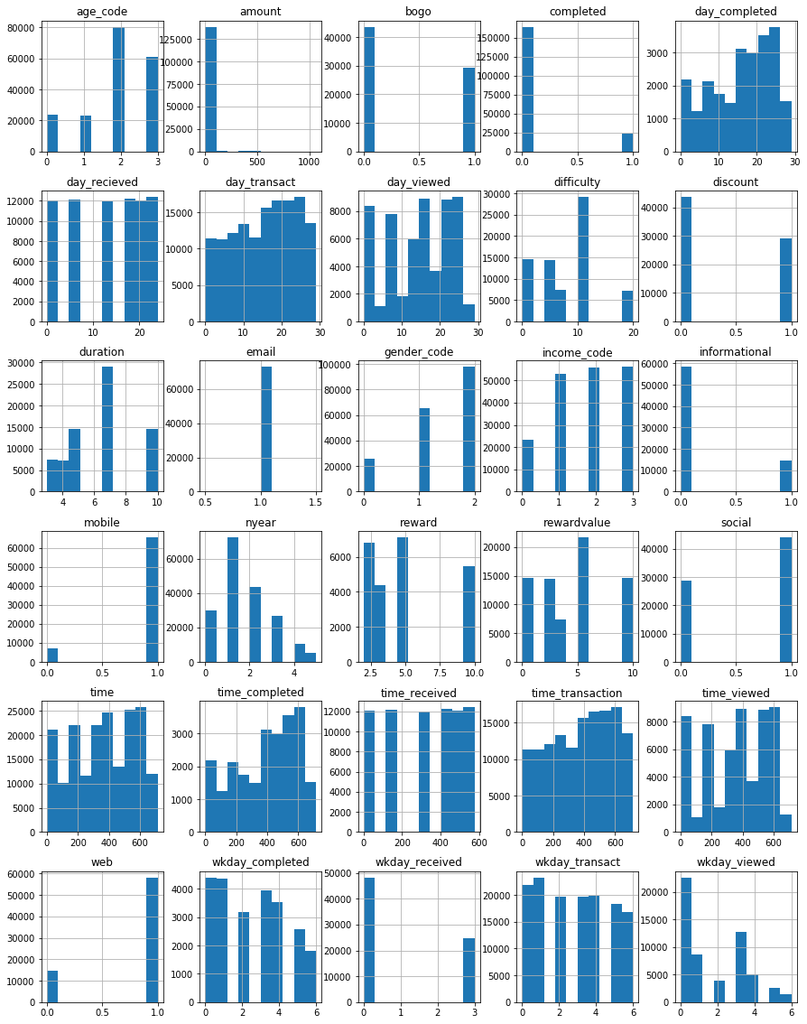

```python
#check numerical variables
df.hist(figsize=(15,20));
```

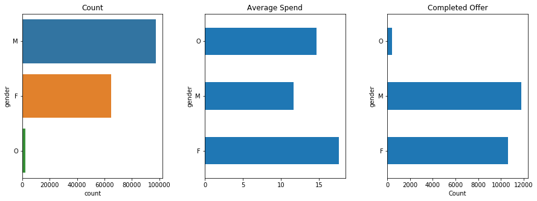

```python
#plot count of gender and correlation to Average and completed offer
plt.subplots(1, 3, figsize=(15, 5))
plt.subplots_adjust(hspace=0.3, wspace=0.3)

plt.subplot(131)
plot_var('gender',df)

plt.subplot(132)
plot_ave('gender', 'amount', df)

plt.subplot(133)
plot_cnt('gender', 'time_completed', df, 'Completed Offer')

plt.show()
```

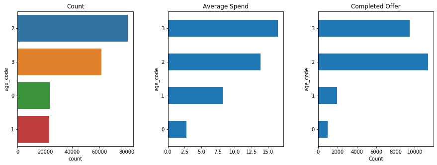

```python
#plot count of age group and correlation to Average, completed transaction
plt.subplots(1, 3, figsize=(15, 5))
plt.subplots_adjust(hspace=0.3, wspace=0.3)

plt.subplot(131)
plot_var('age_code',df)

plt.subplot(132)
plot_ave('age_code', 'amount', df)

plt.subplot(133)
plot_cnt('age_code', 'time_completed', df, 'Completed Offer')

plt.show()
```

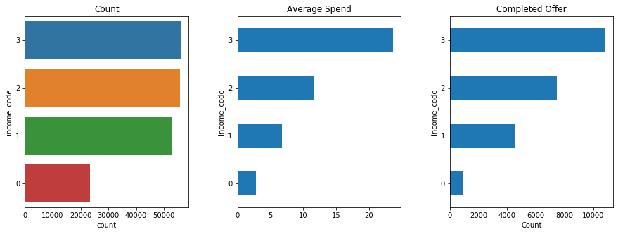

```python
#plot count of income and correlation to Average, completed transaction
plt.subplots(1, 3, figsize=(15, 5))
plt.subplots_adjust(hspace=0.3, wspace=0.3)

plt.subplot(131)
plot_var('income_code',df)

plt.subplot(132)
plot_ave('income_code', 'amount', df)

plt.subplot(133)
plot_cnt('income_code', 'time_completed', df, 'Completed Offer')

plt.show()
```

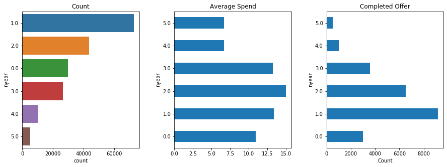

```python
#plot count of membership length and correlation to Average, completed transaction
plt.subplots(1, 3, figsize=(15, 5))
plt.subplots_adjust(hspace=0.3, wspace=0.3)

plt.subplot(131)
plot_var('nyear',df)

plt.subplot(132)
plot_ave('nyear', 'amount', df)

plt.subplot(133)
plot_cnt('nyear', 'time_completed', df, 'Completed Offer')

plt.show()
```

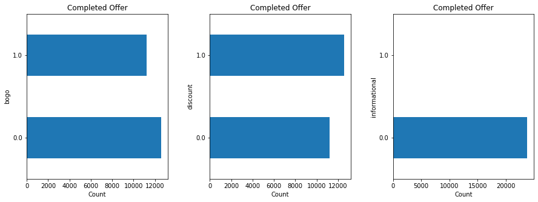

```python
#plot count of offer attributes and correlation to completed transaction
plt.subplots(1, 3, figsize=(15, 5))
plt.subplots_adjust(hspace=0.3, wspace=0.3)

plt.subplot(131)
plot_cnt('bogo', 'time_completed', df, 'Completed Offer')

plt.subplot(132)
plot_cnt('discount', 'time_completed', df, 'Completed Offer')

plt.subplot(133)
plot_cnt('informational', 'time_completed', df, 'Completed Offer')

plt.show()
```

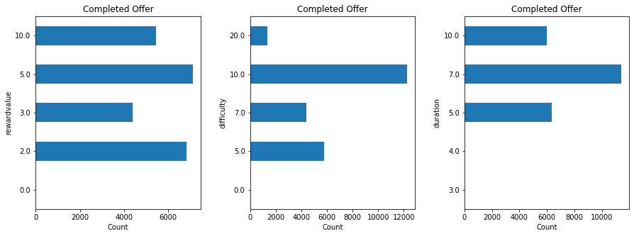

```python
#plot count of bogo and correlation to completed transaction
plt.subplots(1, 3, figsize=(15, 5))
plt.subplots_adjust(hspace=0.3, wspace=0.3)

plt.subplot(131)
plot_cnt('rewardvalue', 'time_completed', df, 'Completed Offer')

plt.subplot(132)
plot_cnt('difficulty', 'time_completed', df, 'Completed Offer')

plt.subplot(133)
plot_cnt('duration', 'time_completed', df, 'Completed Offer')

plt.show()
```

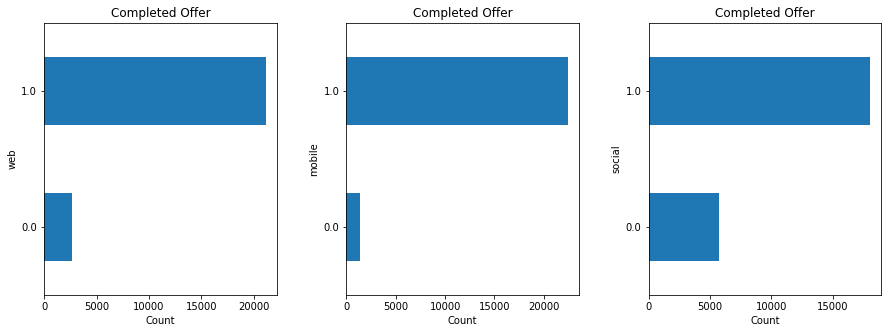

```python
#plot count of channel and correlation to completed transaction
plt.subplots(1, 3, figsize=(15, 5))
plt.subplots_adjust(hspace=0.3, wspace=0.3)

plt.subplot(131)
plot_cnt('web', 'time_completed', df, 'Completed Offer')

plt.subplot(132)
plot_cnt('mobile', 'time_completed', df, 'Completed Offer')

plt.subplot(133)
plot_cnt('social', 'time_completed', df, 'Completed Offer')

plt.show()
```

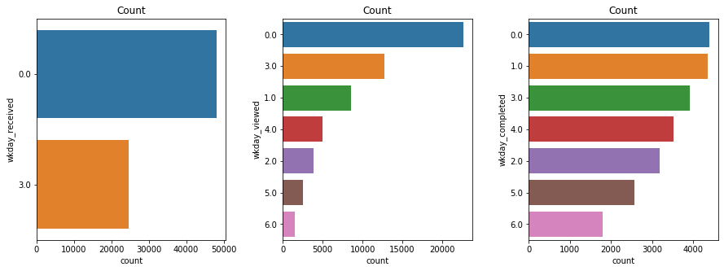

```python
#plot count of offfers viewed, received, completed
plt.subplots(1, 3, figsize=(15, 5))
plt.subplots_adjust(hspace=0.3, wspace=0.3)

plt.subplot(131)
plot_var('wkday_received',df)

plt.subplot(132)
plot_var('wkday_viewed',df)

plt.subplot(133)
plot_var('wkday_completed',df)

plt.show()
```

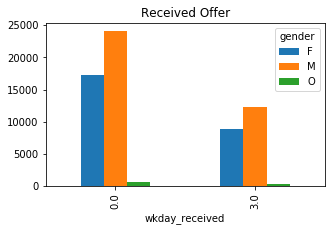

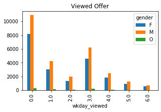

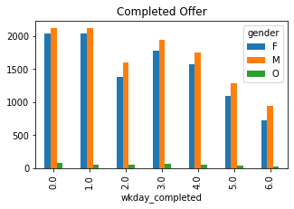

```python
#plot count of offfers viewed, received, completed, by gender
#plt.subplots(1, 3, figsize=(15, 5))
#plt.subplots_adjust(hspace=0.3, wspace=0.3)

#plt.subplot(131)
pltcrosstab('gender', 'wkday_received', df, 'Received Offer')

#plt.subplot(132)
pltcrosstab('gender', 'wkday_viewed', df, 'Viewed Offer')

#plt.subplot(133)
pltcrosstab('gender', 'wkday_completed', df, 'Completed Offer')
```

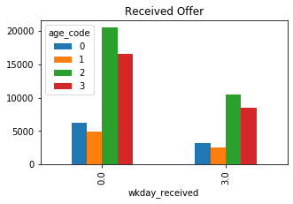

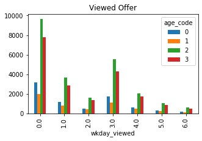

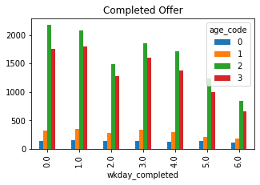

```python
#plot count of offfers viewed, received, completed, by age group
#plt.subplots(1, 3, figsize=(15, 5))
#plt.subplots_adjust(hspace=0.3, wspace=0.3)

#plt.subplot(131)
pltcrosstab('age_code', 'wkday_received', df, 'Received Offer')

#plt.subplot(132)
pltcrosstab('age_code', 'wkday_viewed', df, 'Viewed Offer')

#plt.subplot(133)
pltcrosstab('age_code', 'wkday_completed', df, 'Completed Offer')
```

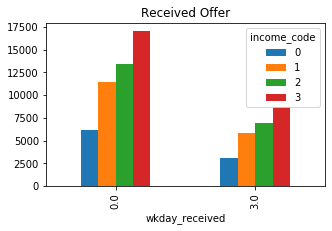

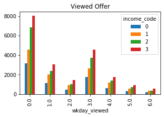

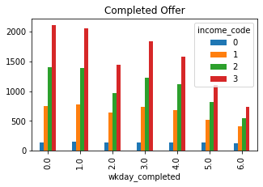

```python
#plot count of offfers viewed, received, completed, by income group
#plt.subplots(1, 3, figsize=(15, 5))
#plt.subplots_adjust(hspace=0.3, wspace=0.3)

#plt.subplot(131)
pltcrosstab('income_code', 'wkday_received', df, 'Received Offer')

#plt.subplot(132)
pltcrosstab('income_code', 'wkday_viewed', df, 'Viewed Offer')

#plt.subplot(133)
pltcrosstab('income_code', 'wkday_completed', df, 'Completed Offer')
```

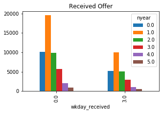

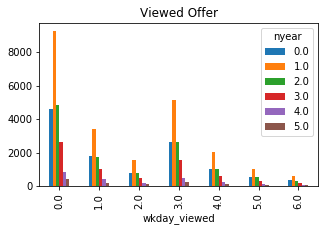

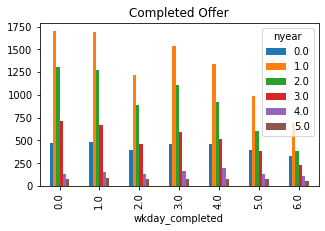

```python
#plot count of offfers viewed, received, completed, by membership lenght
#plt.subplots(1, 3, figsize=(15, 5))
#plt.subplots_adjust(hspace=0.3, wspace=0.3)

#plt.subplot(131)
pltcrosstab('nyear', 'wkday_received', df, 'Received Offer')

#plt.subplot(132)
pltcrosstab('nyear', 'wkday_viewed', df, 'Viewed Offer')

#plt.subplot(133)
pltcrosstab('nyear', 'wkday_completed', df, 'Completed Offer')
```

> Based on the histogram and graphs above, I will use the following variables to build a model
> 1. Customer profile
>    - Age
>    - Gender
>    - Income
>    - Membership Length
> 2. Offer Attributes
>    - Offer Type (BOGO, Discount)
>    - Reward
>    - Difficulty
>    - Day of the Week, Received and Completed
> 3. Completed Offer Flag

### Part IV : Build Model

###### 4.0 Check final data to be used to build a model

```python
df.info()
```

```
<class 'pandas.core.frame.DataFrame'>
Int64Index: 188234 entries, 2 to 188233
Data columns (total 35 columns):
 #   Column            Non-Null Count   Dtype
---  ------            --------------   -----
 0   person            188234 non-null  object
 1   offer_id          72811 non-null   object
 2   time              188234 non-null  float64
 3   time_received     72811 non-null   float64
 4   time_viewed       56819 non-null   float64
 5   time_completed    23770 non-null   float64
 6   time_transaction  139193 non-null  float64
 7   amount            139193 non-null  float64
 8   reward            23770 non-null   float64
 9   rewardvalue       72811 non-null   float64
```

[output cut: 27 more lines]

```python
df_model = df.copy()
```

```python
#the objective is build a model to determine which offer type leads to completion
#Drop all columns not needed for model
df_model.drop(['person','offer_id','time','time_received','time_viewed','time_transaction',
               'amount','reward', 'channels','offer_type','gender', 'email','informational',
               "time_completed", "day_recieved","day_viewed",
               "day_completed","day_transact","web","mobile","social", "wkday_transact"], axis=1, inplace=True)
```

```python
#fill null values
df_model=df_model.fillna(df_model.mode().iloc[0])
```

```python
#check number of records
df_model.shape
```

```
(188234, 13)
```

```python
#check all columns type
df_model.info()
```

```
<class 'pandas.core.frame.DataFrame'>
Int64Index: 188234 entries, 2 to 188233
Data columns (total 13 columns):
 #   Column           Non-Null Count   Dtype
---  ------           --------------   -----
 0   rewardvalue      188234 non-null  float64
 1   difficulty       188234 non-null  float64
 2   duration         188234 non-null  float64
 3   bogo             188234 non-null  float64
 4   discount         188234 non-null  float64
 5   nyear            188234 non-null  float64
 6   gender_code      188234 non-null  int64
 7   income_code      188234 non-null  int64
 8   age_code         188234 non-null  int64
 9   wkday_received   188234 non-null  float64
 10  wkday_viewed     188234 non-null  float64
 11  wkday_completed  188234 non-null  float64
 12  completed        188234 non-null  int64
dtypes: float64(9), int64(4)
memory usage: 20.1 MB
```

###### 4.1 Split Data into training and test datasets

```python
#import libraries needed for prediction, to determine which variables drives the prices
from sklearn.model_selection import train_test_split
```

```python
# Define target and train/test arrays to use
y = df_model['completed']

#remove variables that will not be used
X = df_model.drop(['completed'], axis=1)
```

```python
#Use sklearn train_test_split split the data for test and training randomly, 70% train, 30% test
X_train, X_test, y_train, y_test = train_test_split(X, y, test_size = .70, random_state=0)
```

###### 4.2 Build Model

```python
#Build model using RandomForrestClassifier
from sklearn.ensemble import RandomForestClassifier

clf1 = RandomForestClassifier(random_state=0).fit(X_train, y_train)

#predict
clf1.predict(X_test[:2])

#evaluation score
clf1.score(X_test, y_test)
```

```
0.9772244315594548
```

###### 4.2 Build another model

Build another model to compare results.

```python
#Build another model using GradientBoostingClassifier
from sklearn.ensemble import GradientBoostingClassifier

clf2 = GradientBoostingClassifier(random_state=0).fit(X_train, y_train)

#predict
clf2.predict(X_test[:2])

#evaluation score
clf2.score(X_test, y_test)
```

```
0.9782869372514496
```

### Part V : Model Evaluation

###### 5.1 Extract important features from first model using RandomForestClassifier

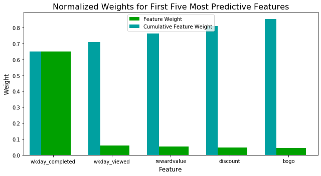

```python
importances1 = clf1.feature_importances_
vs.feature_plot(importances1, X_train, y_train)
```

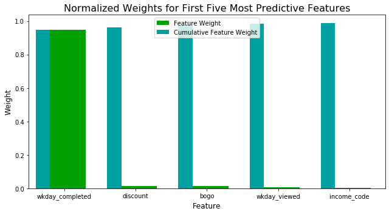

```python
importances2 = clf2.feature_importances_
vs.feature_plot(importances2, X_train, y_train)
```

##### 5.3 Conclusion

Both models resulted to 0.97 score and similar important features that are significant to predictive model. The Random Forest Classifier model top 5 features are: the day of the week the offer was completed (wkday_completed), day of the week the offer was viewed (wkday_viewed), rewardvalue, discount offer type, bogo offer type. The Gradient Boosting Classifier model top 5 features are: the day of the week the offer was completed (wkday_completed), discount offer type, bogo offer type, day of the week the offer was viewed (wkday_viewed), and income_code. Between the two models, the common features that are significat to predictive model are:

(1) day of the week the offer was completed (wkday_completed)  
(2) day of the week the offer was viewed (wkday_viewed)  
(3) discount offer type  
(4) bogo offer type

In addition, based on the result of feature analysis, the relationship or correlation between offer completion, average transaction amount spent, and demographic profile of customers. Male, age group 30-60yo, with income of 70K and higher, and customers within a year are most likely to complete an offer. Additionally, sending the offer to customer on Monday is effective because customers are most likely to complete the offer on Monday and Tuesday, regardless of demographic profile. While Female and Other gender code, spend more than Male.

### Part VI : Implementation

The implementation can be done into the following stages:

1. Save the data into a database (i.e. SQL or DB2)
2. Develop a Jupyter Notebook that will:  
   • Read the data from database  
   • Define callable functions to perform the data cleanup and transformation as implemented in this Jupyter Notebook.  
   • Develop callable functions to perform feature analysis and visualization, which can be deployed into online dashboard.  
   • Define callable functions that will train and execute two predictive models.
3. Deploy the model into a hosting environment and can be called from applications

### References

https://www.datascience-pm.com/crisp-dm-2/  
https://pandas.pydata.org/  
https://matplotlib.org  
https://scikit-learn.org/  
https://seaborn.pydata.org/  
https://numpy.org/